# Admin actions

The basic workflow of Django’s admin is, in a nutshell, “select an object, then change it.” This works well for a majority of use cases. However, if you need to make the same change to many objects at once, this workflow can be quite tedious.

In these cases, Django’s admin lets you write and register “actions” – functions that get called with a list of objects selected on the change list page.

If you look at any change list in the admin, you’ll see this feature in action; Django ships with a “delete selected objects” action available to all models. For example, here’s the user module from Django’s built-in `django.contrib.auth` app:

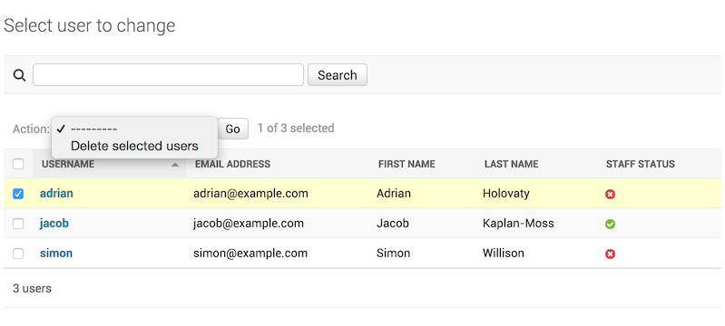

Warning

The “delete selected objects” action uses `QuerySet.delete()` for efficiency reasons, which has an important caveat: your model’s `delete()` method will not be called.

If you wish to override this behavior, you can override `ModelAdmin.delete_queryset()` or write a custom action which does deletion in your preferred manner – for example, by calling `Model.delete()` for each of the selected items.

For more background on bulk deletion, see the documentation on object deletion.

Read on to find out how to add your own actions to this list.

## Writing actions

The easiest way to explain actions is by example, so let’s dive in.

A common use case for admin actions is the bulk updating of a model. Imagine a news application with an `Article` model:

```
from django.db import models

STATUS_CHOICES = [
    ("d", "Draft"),
    ("p", "Published"),
    ("w", "Withdrawn"),
]


class Article(models.Model):
    title = models.CharField(max_length=100)
    body = models.TextField()
    status = models.CharField(max_length=1, choices=STATUS_CHOICES)

    def __str__(self):
        return self.title
```

A common task we might perform with a model like this is to update an article’s status from “draft” to “published”. We could easily do this in the admin one article at a time, but if we wanted to bulk-publish a group of articles, it’d be tedious. So, let’s write an action that lets us change an article’s status to “published.”

### Writing action functions

First, we’ll need to write a function that gets called when the action is triggered from the admin. Action functions are regular functions that take three arguments:

- The current `ModelAdmin`
- An `HttpRequest` representing the current request,
- A `QuerySet` containing the set of objects selected by the user.

Our publish-these-articles function won’t need the `ModelAdmin` or the request object, but we will use the queryset:

```
def make_published(modeladmin, request, queryset):
    queryset.update(status="p")
```

Note

For the best performance, we’re using the queryset’s update method. Other types of actions might need to deal with each object individually; in these cases we’d iterate over the queryset:

```
for obj in queryset:
    do_something_with(obj)
```

That’s actually all there is to writing an action! However, we’ll take one more optional-but-useful step and give the action a “nice” title in the admin. By default, this action would appear in the action list as “Make published” – the function name, with underscores replaced by spaces. That’s fine, but we can provide a better, more human-friendly name by using the `action()` decorator on the `make_published` function:

```
from django.contrib import admin

...


@admin.action(description="Mark selected stories as published")
def make_published(modeladmin, request, queryset):
    queryset.update(status="p")
```

Note

This might look familiar; the admin’s `list_display` option uses a similar technique with the `display()` decorator to provide human-readable descriptions for callback functions registered there, too.

### Adding actions to the `ModelAdmin`

Next, we’ll need to inform our `ModelAdmin` of the action. This works just like any other configuration option. So, the complete `admin.py` with the action and its registration would look like:

```
from django.contrib import admin
from myapp.models import Article


@admin.action(description="Mark selected stories as published")
def make_published(modeladmin, request, queryset):
    queryset.update(status="p")


class ArticleAdmin(admin.ModelAdmin):
    list_display = ["title", "status"]
    ordering = ["title"]
    actions = [make_published]


admin.site.register(Article, ArticleAdmin)
```

That code will give us an admin change list that looks something like this:

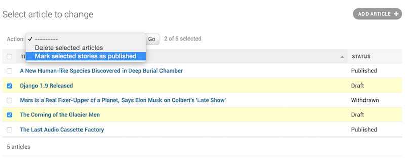

That’s really all there is to it! If you’re itching to write your own actions, you now know enough to get started. The rest of this document covers more advanced techniques.

### Handling errors in actions

If there are foreseeable error conditions that may occur while running your action, you should gracefully inform the user of the problem. This means handling exceptions and using `django.contrib.admin.ModelAdmin.message_user()` to display a user friendly description of the problem in the response.

## Advanced action techniques

There’s a couple of extra options and possibilities you can exploit for more advanced options.

### Actions as `ModelAdmin` methods

The example above shows the `make_published` action defined as a function. That’s perfectly fine, but it’s not perfect from a code design point of view: since the action is tightly coupled to the `Article` object, it makes sense to hook the action to the `ArticleAdmin` object itself.

You can do it like this:

```
class ArticleAdmin(admin.ModelAdmin):
    ...

    actions = ["make_published"]

    @admin.action(description="Mark selected stories as published")
    def make_published(self, request, queryset):
        queryset.update(status="p")
```

Notice first that we’ve moved `make_published` into a method and renamed the `modeladmin` parameter to `self`, and second that we’ve now put the string `'make_published'` in `actions` instead of a direct function reference. This tells the `ModelAdmin` to look up the action as a method.

Defining actions as methods gives the action more idiomatic access to the `ModelAdmin` itself, allowing the action to call any of the methods provided by the admin.

For example, we can use `self` to flash a message to the user informing them that the action was successful:

```
from django.contrib import messages
from django.utils.translation import ngettext


class ArticleAdmin(admin.ModelAdmin):
    ...

    def make_published(self, request, queryset):
        updated = queryset.update(status="p")
        self.message_user(
            request,
            ngettext(
                "%d story was successfully marked as published.",
                "%d stories were successfully marked as published.",
                updated,
            )
            % updated,
            messages.SUCCESS,
        )
```

This make the action match what the admin itself does after successfully performing an action:

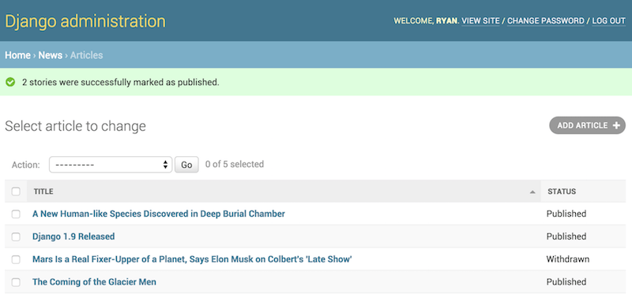

### Actions that provide intermediate pages

By default, after an action is performed the user is redirected back to the original change list page. However, some actions, especially more complex ones, will need to return intermediate pages. For example, the built-in delete action asks for confirmation before deleting the selected objects.

To provide an intermediary page, return an `HttpResponse` (or subclass) from your action. For example, you might write an export function that uses Django’s serialization functions to dump some selected objects as JSON:

```
from django.core import serializers
from django.http import HttpResponse


def export_as_json(modeladmin, request, queryset):
    response = HttpResponse(content_type="application/json")
    serializers.serialize("json", queryset, stream=response)
    return response
```

Generally, something like the above isn’t considered a great idea. Most of the time, the best practice will be to return an `HttpResponseRedirect` and redirect the user to a view you’ve written, passing the list of selected objects in the GET query string. This allows you to provide complex interaction logic on the intermediary pages. For example, if you wanted to provide a more complete export function, you’d want to let the user choose a format, and possibly a list of fields to include in the export. The best thing to do would be to write a small action that redirects to your custom export view:

```
from django.contrib.contenttypes.models import ContentType
from django.http import HttpResponseRedirect


def export_selected_objects(modeladmin, request, queryset):
    selected = queryset.values_list("pk", flat=True)
    ct = ContentType.objects.get_for_model(queryset.model)
    return HttpResponseRedirect(
        "/export/?ct=%s&ids=%s"
        % (
            ct.pk,
            ",".join(str(pk) for pk in selected),
        )
    )
```

As you can see, the action is rather short; all the complex logic would belong in your export view. This would need to deal with objects of any type, hence the business with the `ContentType`.

Writing this view is left as an exercise to the reader.

### Making actions available site-wide

**`AdminSite.add_action(action, name=None)`**

Some actions are best if they’re made available to *any* object in the admin site – the export action defined above would be a good candidate. You can make an action globally available using `AdminSite.add_action()`. For example:

```
from django.contrib import admin

admin.site.add_action(export_selected_objects)
```

This makes the `export_selected_objects` action globally available as an action named “export_selected_objects”. You can explicitly give the action a name – good if you later want to programmatically remove the action – by passing a second argument to `AdminSite.add_action()`:

```
admin.site.add_action(export_selected_objects, "export_selected")
```

### Disabling actions

Sometimes you need to disable certain actions – especially those registered site-wide – for particular objects. There’s a few ways you can disable actions:

#### Disabling a site-wide action

**`AdminSite.disable_action(name)`**

If you need to disable a site-wide action you can call `AdminSite.disable_action()`.

For example, you can use this method to remove the built-in “delete selected objects” action:

```
admin.site.disable_action("delete_selected")
```

Once you’ve done the above, that action will no longer be available site-wide.

If, however, you need to reenable a globally-disabled action for one particular model, list it explicitly in your `ModelAdmin.actions` list:

```
# Globally disable delete selected
admin.site.disable_action("delete_selected")


# This ModelAdmin will not have delete_selected available
class SomeModelAdmin(admin.ModelAdmin):
    actions = ["some_other_action"]
    ...


# This one will
class AnotherModelAdmin(admin.ModelAdmin):
    actions = ["delete_selected", "a_third_action"]
    ...
```

#### Disabling all actions for a particular `ModelAdmin`

If you want *no* bulk actions available for a given `ModelAdmin`, set `ModelAdmin.actions` to `None`:

```
class MyModelAdmin(admin.ModelAdmin):
    actions = None
```

This tells the `ModelAdmin` to not display or allow any actions, including any site-wide actions.

#### Conditionally enabling or disabling actions

**`ModelAdmin.get_actions(request)`**

Finally, you can conditionally enable or disable actions on a per-request (and hence per-user basis) by overriding `ModelAdmin.get_actions()`.

This returns a dictionary of actions allowed. The keys are action names, and the values are `(function, name, short_description)` tuples.

For example, if you only want users whose names begin with ‘J’ to be able to delete objects in bulk:

```
class MyModelAdmin(admin.ModelAdmin):
    ...

    def get_actions(self, request):
        actions = super().get_actions(request)
        if request.user.username[0].upper() != "J":
            if "delete_selected" in actions:
                del actions["delete_selected"]
        return actions
```

### Setting permissions for actions

Actions may limit their availability to users with specific permissions by wrapping the action function with the `action()` decorator and passing the `permissions` argument:

```
@admin.action(permissions=["change"])
def make_published(modeladmin, request, queryset):
    queryset.update(status="p")
```

The `make_published()` action will only be available to users that pass the `ModelAdmin.has_change_permission()` check.

If `permissions` has more than one permission, the action will be available as long as the user passes at least one of the checks.

Available values for `permissions` and the corresponding method checks are:

- `'add'`: `ModelAdmin.has_add_permission()`
- `'change'`: `ModelAdmin.has_change_permission()`
- `'delete'`: `ModelAdmin.has_delete_permission()`
- `'view'`: `ModelAdmin.has_view_permission()`

You can specify any other value as long as you implement a corresponding `has_<value>_permission(self, request)` method on the `ModelAdmin`.

For example:

```
from django.contrib import admin
from django.contrib.auth import get_permission_codename


class ArticleAdmin(admin.ModelAdmin):
    actions = ["make_published"]

    @admin.action(permissions=["publish"])
    def make_published(self, request, queryset):
        queryset.update(status="p")

    def has_publish_permission(self, request):
        """Does the user have the publish permission?"""
        opts = self.opts
        codename = get_permission_codename("publish", opts)
        return request.user.has_perm("%s.%s" % (opts.app_label, codename))
```

## The `action` decorator

**`action(*, permissions=None, description=None)`**

This decorator can be used for setting specific attributes on custom action functions that can be used with `actions`:

```
@admin.action(
    permissions=["publish"],
    description="Mark selected stories as published",
)
def make_published(self, request, queryset):
    queryset.update(status="p")
```

This is equivalent to setting some attributes (with the original, longer names) on the function directly:

```
def make_published(self, request, queryset):
    queryset.update(status="p")


make_published.allowed_permissions = ["publish"]
make_published.short_description = "Mark selected stories as published"
```

Use of this decorator is not compulsory to make an action function, but it can be useful to use it without arguments as a marker in your source to identify the purpose of the function:

```
@admin.action
def make_inactive(self, request, queryset):
    queryset.update(is_active=False)
```

In this case it will add no attributes to the function.

Action descriptions are %-formatted and may contain `'%(verbose_name)s'` and `'%(verbose_name_plural)s'` placeholders, which are replaced, respectively, by the model’s `verbose_name` and `verbose_name_plural`.

© Django Software Foundation and individual contributors  
Licensed under the BSD License.  
https://docs.djangoproject.com/en/4.2/ref/contrib/admin/actions/